# Understanding moneca Statistics: A Comprehensive Guide

Giampaolo Montaletti

2025-09-02

## Introduction

The `print.moneca()` function provides a comprehensive summary of mobility analysis results from the MONECA clustering algorithm. This vignette explains each statistic in detail with clear definitions, computational formulas, interpretations, and practical examples. The output is structured to follow the natural flow of analysis from overall patterns to detailed network metrics.

## Overview of MONECA Output

When you run a MONECA analysis and print the results, you receive a structured report organized into four main sections:

1. **Overall Mobility Patterns** - Population-level mobility summary
2. **Hierarchical Segmentation Analysis** - Level-by-level clustering results
3. **Network Structure Metrics** - Graph-theoretic properties
4. **Detailed Degree Distributions** - Node connectivity statistics (optional)

Let’s start with a complete example:

```r
# Generate synthetic mobility data with 30 classes for better statistical analysis
mobility_data <- generate_mobility_data(
  n_classes = 30,
  n_total = 60000,  # Larger population for better statistics
  immobility_strength = 0.7,
  class_clustering = 0.8,
  class_names = paste("Class", sprintf("%02d", 1:30)),
  seed = 123
)

cat("Mobility data dimensions:", dim(mobility_data), "\n")
```

```
#> Mobility data dimensions: 31 31
```

```r
cat("Total population:", mobility_data[31, 31], "\n")
```

```
#> Total population: 60000
```

```r
cat("Overall mobility rate:",
    round((1 - sum(diag(mobility_data[1:30, 1:30])) / sum(mobility_data[1:30, 1:30])) * 100, 1), "%\n\n")
```

```
#> Overall mobility rate: 63.5 %
```

```r
# Show a representative subset of the mobility matrix
cat("Representative 8x8 subset of mobility matrix:\n")
```

```
#> Representative 8x8 subset of mobility matrix:
```

```r
subset_indices <- c(1:6, 15:16)  # First 6 classes plus middle classes
subset_matrix <- mobility_data[c(subset_indices, 31), c(subset_indices, 31)]
print(subset_matrix)
```

```
#>          Class 01 Class 02 Class 03 Class 04 Class 05 Class 06 Class 15
#> Class 01      573      331      158        1        1        3        1
#> Class 02      937     1609      933      474        8        8        6
#> Class 03       19       29       71       36       20        0        0
#> Class 04        1      202      411      708      466      199        1
#> Class 05       10        5      561     1086     1892     1106        9
#> Class 06        3        2        6      295      597      933        6
#> Class 15        1        8        2        5        9        2     1203
#> Class 16        6        3        4        4        2        2      330
#> Total        1606     2265     2210     2673     3107     2423     2721
#>          Class 16 Total
#> Class 01        0  1130
#> Class 02        4  4135
#> Class 03        0   180
#> Class 04        4  2076
#> Class 05       10  5414
#> Class 06        3  2644
#> Class 15      672  3348
#> Class 16      680  1788
#> Total        2231 60000
```

```r
# Run MONECA analysis
seg <- moneca(mobility_data, segment.levels = 3, small.cell.reduction = 10)
```

[output not shown]

```r
# Display results
print(seg)
```

```
#>
#> ================================================================================
#>                         moneca MOBILITY ANALYSIS RESULTS
#> ================================================================================
#>
#> OVERALL MOBILITY PATTERNS
#> -------------------------------------------------------------------------------
#> Overall Population Mobility Rate:                    63.5%
#> Average Mobility Concentration (all levels):         91.0%
#>
#> HIERARCHICAL SEGMENTATION ANALYSIS
#> -------------------------------------------------------------------------------
#>
#> Internal Mobility Within Segments (%):
#> Level 1 Level 2 Level 3 Level 4
#>    36.5    63.8    79.4    88.5
#>
#> Mobility Concentration in Significant Pathways by Level (%):
#> Level 1 Level 2 Level 3 Level 4
#>    95.7    94.4    85.5    88.5
#>
#> Network Structure by Level:
#>                                    Level 1      Level 2      Level 3      Level 4
#> -------------------------------------------------------------------------------
#> Active Segments/Classes:                30           12            7            4
#> Significant Edges:                     113           21            3            0
#> Network Density:                     0.130        0.159        0.071        0.000
#> Isolated Segments:                       0            0            3            4
#>
#> DETAILED WEIGHTED DEGREE DISTRIBUTIONS (STRENGTH)
#> -------------------------------------------------------------------------------
#>
#> Total Weighted Connections (Strength In + Out):
#>           Min    Q1 Median  Mean    Q3   Max
#> Level 1 19.67 29.20  32.00 41.92 46.63 97.97
#> Level 2  2.60  7.47   8.26  8.20 10.06 11.79
#> Level 3  0.00  0.00   1.10  1.03  1.80  2.50
#> Level 4  0.00  0.00   0.00  0.00  0.00  0.00
#>
#> Outward Mobility Strength (Weighted Out-Degree):
#>          Min    Q1 Median  Mean    Q3   Max
#> Level 1 9.61 14.91  16.74 20.96 24.43 43.50
#> Level 2 1.03  3.52   4.08  4.10  5.33  6.12
#> Level 3 0.00  0.00   0.00  0.52  1.15  1.30
#> Level 4 0.00  0.00   0.00  0.00  0.00  0.00
#>
#> Inward Mobility Strength (Weighted In-Degree):
#>           Min    Q1 Median  Mean    Q3   Max
#> Level 1 10.05 13.54  15.82 20.96 23.05 55.64
#> Level 2  1.57  2.87   4.13  4.10  5.01  7.49
#> Level 3  0.00  0.00   0.00  0.52  1.15  1.30
#> Level 4  0.00  0.00   0.00  0.00  0.00  0.00
#>
#> Edge Weight Distribution (Relative Risk Values):
#>          Min   Q1 Median Mean   Q3   Max
#> Level 1 1.65 3.06   4.54 5.56 6.87 23.41
#> Level 2 1.03 1.57   2.33 2.34 2.71  4.01
#> Level 3 1.10 1.15   1.20 1.20 1.25  1.30
#> Level 4   NA   NA     NA  NaN   NA    NA
#>
#> ================================================================================
```

## Statistics Explained

### 1. Overall Mobility Patterns

#### Overall Population Mobility Rate

**Definition:** The percentage of the total population that experiences any form of social mobility (movement between social classes).

**Calculation:**
$$\text{Mobility Rate} = \frac{\sum_{i \neq j}
n_{ij}}{N} \times 100$$

Where: - $n_{ij}$ = count in cell (i,j) of the mobility table - $N$ = grand total (bottom-right cell) - The sum excludes diagonal cells (i=j)

**Interpretation:** - Values range from 0% (complete immobility) to 100% (everyone moves) - Higher values indicate more fluid social structures - Lower values suggest more rigid class boundaries - Typical values in real data: 15-40%

```r
# Access the raw mobility rate from 30x30 matrix
mx <- seg$mat.list[[1]]
l <- ncol(mx)
total_population <- mx[l, l]

# Calculate mobility components
immobile_population <- sum(diag(mx[1:(l-1), 1:(l-1)]))  # Diagonal elements
mobile_population <- total_population - immobile_population
mobility_rate <- mobile_population / total_population

cat("Population statistics:\n")
```

```
#> Population statistics:
```

```r
cat("Total population:", total_population, "\n")
```

```
#> Total population: 60000
```

```r
cat("Immobile population:", immobile_population, "\n")
```

```
#> Immobile population: 21924
```

```r
cat("Mobile population:", mobile_population, "\n")
```

```
#> Mobile population: 38076
```

```r
cat("Raw mobility rate:", round(mobility_rate * 100, 1), "%\n")
```

```
#> Raw mobility rate: 63.5 %
```

```r
# Show mobility rates by class groups for first 10 classes
cat("\nMobility rates by class (first 10 classes):\n")
```

```
#>
#> Mobility rates by class (first 10 classes):
```

```r
for(i in 1:10) {
  class_total <- mx[i, l]
  class_immobile <- mx[i, i]
  class_mobile <- class_total - class_immobile
  class_mobility_rate <- class_mobile / class_total
  cat("Class", sprintf("%02d", i), ":", round(class_mobility_rate * 100, 1), "%\n")
}
```

```
#> Class 01 : 49.3 %
#> Class 02 : 61.1 %
#> Class 03 : 60.6 %
#> Class 04 : 65.9 %
#> Class 05 : 65.1 %
#> Class 06 : 64.7 %
#> Class 07 : 65.4 %
#> Class 08 : 58.6 %
#> Class 09 : 64.1 %
#> Class 10 : 65.7 %
```

#### Average Mobility Concentration

**Definition:** The mean percentage of all mobility that occurs through statistically significant pathways (edges with relative risk > 1) across all hierarchical levels.

**Calculation:**
$$\text{Concentration}_\ell = \frac{\sum_{RR_{ij}
> 1} n_{ij}}{\sum_{i} \text{rowSum}_i} \times 100$$

$$\text{Average Concentration} =
\frac{1}{L} \sum_{\ell=1}^{L} \text{Concentration}_\ell$$

Where: - $RR_{ij}$ = relative risk for edge (i,j) - $L$ = number of hierarchical levels - Only edges with $RR > 1$ are considered significant

**Interpretation:** - Higher values (>80%) indicate mobility follows predictable, structured patterns - Lower values suggest more random or dispersed mobility - This metric helps assess whether mobility has clear “highways” or is more diffuse

### 2. Hierarchical Segmentation Analysis

#### Internal Mobility Within Segments

**Definition:** For each hierarchical level, the percentage of mobility that occurs within segments (clusters) rather than between them.

**Calculation:** For level $\ell$:
$$\text{Internal Mobility}_\ell = \frac{\sum_{k}
n_{kk}^{(\ell)}}{\sum_{i,j} n_{ij}^{(\ell)}} \times 100$$

Where: - $n_{kk}^{(\ell)}$ = diagonal entries in the level $\ell$ aggregated matrix - $n_{ij}^{(\ell)}$ = all entries in the level $\ell$ matrix

```r
# Show how internal mobility is calculated for Level 1 (30x30 system)
mx <- seg$mat.list[[1]]
l <- ncol(mx)
diagonal_sum <- sum(diag(mx[1:(l-1), 1:(l-1)]))
total_mobility <- sum(mx[1:(l-1), 1:(l-1)])
internal_mobility_pct <- (diagonal_sum / total_mobility) * 100

cat("Level 1 internal mobility calculation:\n")
```

```
#> Level 1 internal mobility calculation:
```

```r
cat("Diagonal sum (immobile):", diagonal_sum, "\n")
```

```
#> Diagonal sum (immobile): 21924
```

```r
cat("Total mobility:", total_mobility, "\n")
```

```
#> Total mobility: 60000
```

```r
cat("Internal mobility percentage:", round(internal_mobility_pct, 1), "%\n")
```

```
#> Internal mobility percentage: 36.5 %
```

```r
# Show how this progresses across levels
cat("\nInternal mobility progression across levels:\n")
```

```
#>
#> Internal mobility progression across levels:
```

```r
for(level in 1:length(seg$mat.list)) {
  level_mx <- seg$mat.list[[level]]
  level_l <- ncol(level_mx)
  level_diagonal <- sum(diag(level_mx[1:(level_l-1), 1:(level_l-1)]))
  level_total <- sum(level_mx[1:(level_l-1), 1:(level_l-1)])
  level_internal_pct <- (level_diagonal / level_total) * 100
  n_segments <- level_l - 1
  cat("Level", level, ":", round(level_internal_pct, 1), "% (", n_segments, "segments)\n")
}
```

```
#> Level 1 : 36.5 % ( 30 segments)
#> Level 2 : 63.8 % ( 12 segments)
#> Level 3 : 79.4 % ( 7 segments)
#> Level 4 : 88.5 % ( 4 segments)
```

#### Mobility Concentration in Significant Pathways by Level

**Definition:** For each level, the percentage of mobility that flows through statistically significant pathways (those with relative risk > 1).

**Interpretation:** - Shows how “channeled” mobility is at each level - Higher values indicate more structured mobility patterns - Useful for comparing how well each level captures mobility structure

### 3. Network Structure Metrics

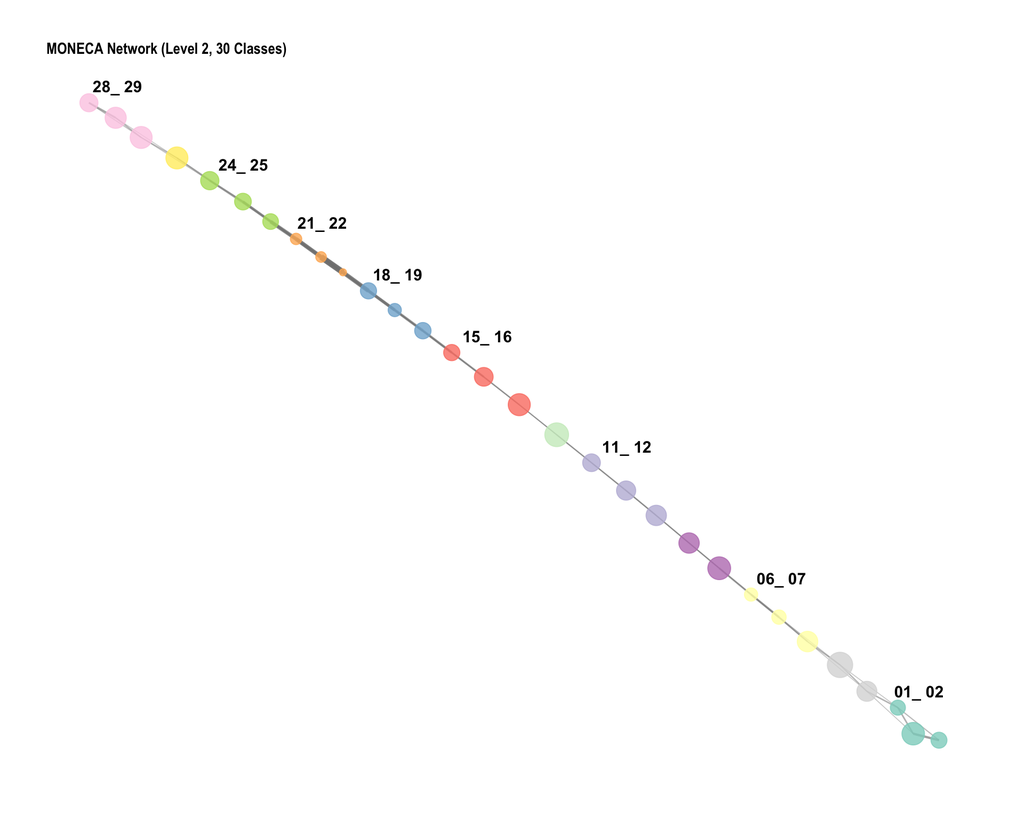

Network visualization showing segments and connections in 30-class system

```r
# Visualize the network at Level 2 for 30-class system
# Note: Labels are turned off for clarity with 30 nodes
plot_moneca_ggraph(seg, level = 2,
                   node_color = "segment",
                   edge_width = "weight",
                   layout = "fr",
                   show_labels = FALSE,  # Too cluttered for 30 nodes
                   node_alpha = 0.8,
                   edge_alpha = 0.6,
                   title = "MONECA Network (Level 2, 30 Classes)",
                   show_segments = TRUE,
                   segment_alpha = 0.2)
```

```r
# Provide network statistics
cat("\nLevel 2 network statistics:\n")
```

```
#>
#> Level 2 network statistics:
```

```r
cat("Number of segments:", length(seg$segment.list[[2]]), "\n")
```

```
#> Number of segments: 10
```

```r
segment_sizes <- sapply(seg$segment.list[[2]], length)
cat("Segment sizes:", paste(sort(segment_sizes, decreasing = TRUE), collapse = ", "), "\n")
```

```
#> Segment sizes: 3, 3, 3, 3, 3, 3, 3, 3, 2, 2
```

```r
cat("Average segment size:", round(mean(segment_sizes), 1), "classes\n")
```

```
#> Average segment size: 2.8 classes
```

```r
cat("Largest segment size:", max(segment_sizes), "classes\n")
```

```
#> Largest segment size: 3 classes
```

```r
cat("Smallest segment size:", min(segment_sizes), "classes\n")
```

```
#> Smallest segment size: 2 classes
```

#### Active Segments/Classes per Level

**Definition:** The number of distinct segments or classes at each hierarchical level.

#### Significant Edges After Cell Size Filtering

**Definition:** The count of statistically significant mobility pathways after removing those based on small cell sizes.

**Interpretation:** - More edges = more complex mobility patterns - Decrease across levels shows simplification of structure - Zero edges would indicate completely isolated segments

#### Network Connectivity Density

**Definition:** The proportion of possible edges that actually exist in the network after removing edges with relative risk ≤ 1.

**Calculation:**
$$\text{Density} = \frac{\text{Actual
Edges}}{\text{Possible Edges}} = \frac{|E|}{n(n-1)}$$

Where: - $|E|$ = number of edges with relative risk > 1 - $n$ = number of nodes (active segments) - For directed networks, possible edges = $n(n-1)$ - Self-loops are excluded

#### Isolated Segments

**Definition:** The count of segments/classes with no statistically significant mobility connections to other segments. A segment is isolated if it has degree = 0 in the network (no edges with relative risk > 1).

**Technical Details:** - Calculated as nodes with total degree = 0 after filtering edges by relative risk - Isolates can still have internal mobility (high diagonal values) - Different from segments of size 1, which are removed before analysis

**Interpretation:** - Higher numbers indicate fragmented social structure - Zero isolates means all segments are connected via significant pathways - Isolates may represent: - Truly closed social groups with only internal mobility - Positions that exchange members only weakly with others - Categories at the extremes of the social hierarchy

### 4. Detailed Degree Distributions

When `show.degree.stats = TRUE` (default), additional network statistics are displayed:

```r
# Show results without degree statistics for comparison
print(seg, show.degree.stats = FALSE)
```

```
#>
#> ================================================================================
#>                         moneca MOBILITY ANALYSIS RESULTS
#> ================================================================================
#>
#> OVERALL MOBILITY PATTERNS
#> -------------------------------------------------------------------------------
#> Overall Population Mobility Rate:                    63.5%
#> Average Mobility Concentration (all levels):         91.0%
#>
#> HIERARCHICAL SEGMENTATION ANALYSIS
#> -------------------------------------------------------------------------------
#>
#> Internal Mobility Within Segments (%):
#> Level 1 Level 2 Level 3 Level 4
#>    36.5    63.8    79.4    88.5
#>
#> Mobility Concentration in Significant Pathways by Level (%):
#> Level 1 Level 2 Level 3 Level 4
#>    95.7    94.4    85.5    88.5
#>
#> Network Structure by Level:
#>                                    Level 1      Level 2      Level 3      Level 4
#> -------------------------------------------------------------------------------
#> Active Segments/Classes:                30           12            7            4
#> Significant Edges:                     113           21            3            0
#> Network Density:                     0.130        0.159        0.071        0.000
#> Isolated Segments:                       0            0            3            4
#>
#> ================================================================================
```

#### Reading the Distribution Tables

Each table shows six statistics: - **Min:** Lowest value in the distribution - **Q1:** First quartile (25th percentile) - **Median:** Middle value (50th percentile) - **Mean:** Average value - **Q3:** Third quartile (75th percentile) - **Max:** Highest value in the distribution

## Practical Interpretation Guide

### Example Interpretation

Let’s interpret our example results:

```r
# Create a different mobility pattern for comparison (30x30)
mobility_data2 <- generate_mobility_data(
  n_classes = 30,
  n_total = 45000,
  immobility_strength = 0.9,  # Much less mobility
  class_clustering = 0.5,     # Less structured
  class_names = paste("Class", sprintf("%02d", 1:30)),
  seed = 456
)

seg2 <- moneca(mobility_data2, segment.levels = 3, small.cell.reduction = 10)
```

[output not shown]

```r
cat("Comparison of two 30-class mobility systems:\n\n")
```

```
#> Comparison of two 30-class mobility systems:
```

```r
# Calculate key statistics for comparison
compare_stats <- function(seg_obj, data_matrix, system_name) {
  mx <- seg_obj$mat.list[[1]]
  l <- ncol(mx)
  total_pop <- mx[l, l]
  mobile_pop <- total_pop - sum(diag(mx[1:(l-1), 1:(l-1)]))
  mobility_rate <- mobile_pop / total_pop * 100

  n_segments_l2 <- length(seg_obj$segment.list[[2]])
  n_segments_l3 <- length(seg_obj$segment.list[[3]])

  # Internal mobility at level 2
  mx2 <- seg_obj$mat.list[[2]]
  l2 <- ncol(mx2)
  internal_l2 <- sum(diag(mx2[1:(l2-1), 1:(l2-1)])) / sum(mx2[1:(l2-1), 1:(l2-1)]) * 100

  cat(system_name, ":\n")
  cat("  Overall mobility rate:", round(mobility_rate, 1), "%\n")
  cat("  Segments at Level 2:", n_segments_l2, "\n")
  cat("  Segments at Level 3:", n_segments_l3, "\n")
  cat("  Internal mobility (L2):", round(internal_l2, 1), "%\n")
  cat("  Population:", total_pop, "\n\n")
}

compare_stats(seg, mobility_data, "System 1 (More fluid, clustering=0.8)")
```

```
#> System 1 (More fluid, clustering=0.8) :
#>   Overall mobility rate: 63.5 %
#>   Segments at Level 2: 10
#>   Segments at Level 3: 5
#>   Internal mobility (L2): 63.8 %
#>   Population: 60000
```

```r
compare_stats(seg2, mobility_data2, "System 2 (More rigid, clustering=0.5)")
```

```
#> System 2 (More rigid, clustering=0.5) :
#>   Overall mobility rate: 47.6 %
#>   Segments at Level 2: 11
#>   Segments at Level 3: 5
#>   Internal mobility (L2): 74.2 %
#>   Population: 45000
```

```r
cat("System 1 (More fluid) - detailed output:\n")
```

```
#> System 1 (More fluid) - detailed output:
```

```r
print(seg, show.degree.stats = FALSE, digits = 1)
```

```
#>
#> ================================================================================
#>                         moneca MOBILITY ANALYSIS RESULTS
#> ================================================================================
#>
#> OVERALL MOBILITY PATTERNS
#> -------------------------------------------------------------------------------
#> Overall Population Mobility Rate:                    63.5%
#> Average Mobility Concentration (all levels):         91.0%
#>
#> HIERARCHICAL SEGMENTATION ANALYSIS
#> -------------------------------------------------------------------------------
#>
#> Internal Mobility Within Segments (%):
#> Level 1 Level 2 Level 3 Level 4
#>    36.5    63.8    79.4    88.5
#>
#> Mobility Concentration in Significant Pathways by Level (%):
#> Level 1 Level 2 Level 3 Level 4
#>    95.7    94.4    85.5    88.5
#>
#> Network Structure by Level:
#>                                    Level 1      Level 2      Level 3      Level 4
#> -------------------------------------------------------------------------------
#> Active Segments/Classes:                30           12            7            4
#> Significant Edges:                     113           21            3            0
#> Network Density:                     0.130        0.159        0.071        0.000
#> Isolated Segments:                       0            0            3            4
#>
#> ================================================================================
```

```r
cat("\n\nSystem 2 (More rigid) - detailed output:\n")
```

```
#>
#>
#> System 2 (More rigid) - detailed output:
```

```r
print(seg2, show.degree.stats = FALSE, digits = 1)
```

```
#>
#> ================================================================================
#>                         moneca MOBILITY ANALYSIS RESULTS
#> ================================================================================
#>
#> OVERALL MOBILITY PATTERNS
#> -------------------------------------------------------------------------------
#> Overall Population Mobility Rate:                    47.6%
#> Average Mobility Concentration (all levels):         89.7%
#>
#> HIERARCHICAL SEGMENTATION ANALYSIS
#> -------------------------------------------------------------------------------
#>
#> Internal Mobility Within Segments (%):
#> Level 1 Level 2 Level 3 Level 4
#>    52.4    74.2    85.2    87.3
#>
#> Mobility Concentration in Significant Pathways by Level (%):
#> Level 1 Level 2 Level 3 Level 4
#>    94.8    89.9    86.7    87.3
#>
#> Network Structure by Level:
#>                                    Level 1      Level 2      Level 3      Level 4
#> -------------------------------------------------------------------------------
#> Active Segments/Classes:                30           11            6            5
#> Significant Edges:                     113           13            1            0
#> Network Density:                     0.130        0.118        0.033        0.000
#> Isolated Segments:                       0            1            4            5
#>
#> ================================================================================
```

## Understanding the Computational Process

### Relative Risk Calculation

The foundation of MONECA is the relative risk matrix, calculated as:

```r
# Demonstrate relative risk calculation for 30x30 matrix
mx <- seg$mat.list[[1]]
l <- nrow(mx)

# Extract marginals
row_totals <- mx[-l, l]
col_totals <- mx[l, -l]
grand_total <- mx[l, l]

cat("Relative risk calculation components:\n")
```

```
#> Relative risk calculation components:
```

```r
cat("Matrix dimensions:", dim(mx), "\n")
```

```
#> Matrix dimensions: 31 31
```

```r
cat("Grand total:", grand_total, "\n")
```

```
#> Grand total: 60000
```

```r
cat("Row totals range:", min(row_totals), "-", max(row_totals), "\n")
```

```
#> Row totals range: 162 - 5414
```

```r
cat("Column totals range:", min(col_totals), "-", max(col_totals), "\n\n")
```

```
#> Column totals range: 708 - 3107
```

```r
# Calculate expected values under independence
expected <- outer(row_totals, col_totals) / grand_total

# Calculate relative risks
observed <- mx[-l, -l]
relative_risk <- observed / expected

# Show subset of relative risk matrix
cat("Sample of relative risk matrix (first 8x8):\n")
```

```
#> Sample of relative risk matrix (first 8x8):
```

```r
print(round(relative_risk[1:8, 1:8], 2))
```

```
#>          Class 01 Class 02 Class 03 Class 04 Class 05 Class 06 Class 07
#> Class 01    18.94     7.76     3.80     0.02     0.02     0.07     0.03
#> Class 02     8.47    10.31     6.13     2.57     0.04     0.05     0.06
#> Class 03     3.94     4.27    10.71     4.49     2.15     0.00     0.00
#> Class 04     0.02     2.58     5.37     7.66     4.33     2.37     0.05
#> Class 05     0.07     0.02     2.81     4.50     6.75     5.06     3.65
#> Class 06     0.04     0.02     0.06     2.50     4.36     8.74     6.14
#> Class 07     0.00     0.00     0.00     0.05     1.99     5.21    12.11
#> Class 08     0.00     0.00     0.17     0.00     0.00     3.06     7.36
#>          Class 08
#> Class 01     0.03
#> Class 02     0.07
#> Class 03     0.00
#> Class 04     0.04
#> Class 05     0.09
#> Class 06     3.53
#> Class 07     7.85
#> Class 08    15.26
```

```r
# Show distribution of relative risk values
rr_diagonal <- diag(relative_risk)
rr_offdiagonal <- relative_risk[upper.tri(relative_risk) | lower.tri(relative_risk)]

cat("\nRelative risk statistics:\n")
```

```
#>
#> Relative risk statistics:
```

```r
cat("Diagonal (immobility) RR - Mean:", round(mean(rr_diagonal), 2),
    "Range:", round(min(rr_diagonal), 2), "-", round(max(rr_diagonal), 2), "\n")
```

```
#> Diagonal (immobility) RR - Mean: 12.89 Range: 6.75 - 30.01
```

```r
cat("Off-diagonal (mobility) RR - Mean:", round(mean(rr_offdiagonal), 2),
    "Range:", round(min(rr_offdiagonal), 2), "-", round(max(rr_offdiagonal), 2), "\n")
```

```
#> Off-diagonal (mobility) RR - Mean: 0.78 Range: 0 - 23.41
```

```r
# Count significant edges
significant_edges <- sum(relative_risk > 1 & !is.na(relative_risk))
total_possible <- 30 * 30
cat("Significant edges (RR > 1):", significant_edges, "out of", total_possible,
    "(", round(significant_edges/total_possible*100, 1), "%)\n")
```

```
#> Significant edges (RR > 1): 144 out of 900 ( 16 %)
```

### Clique Detection Process

MONECA identifies segments through clique detection in the weighted network:

1. Convert relative risk matrix to adjacency matrix (RR > 1)
2. Find all maximal cliques in the resulting graph
3. Select cliques that maximize internal mobility
4. Assign each node to its best clique based on connection strength

### Hierarchical Aggregation

After identifying segments at each level:

```r
# Show how matrices are aggregated across levels in 30-class system
cat("Matrix dimensions across hierarchical levels:\n")
```

```
#> Matrix dimensions across hierarchical levels:
```

```r
for(level in 1:length(seg$mat.list)) {
  dims <- dim(seg$mat.list[[level]])
  n_classes <- dims[1] - 1
  total_pop <- seg$mat.list[[level]][dims[1], dims[2]]
  cat("Level", level, ":", dims[1], "x", dims[2], "(", n_classes, "classes/segments,",
      "population:", total_pop, ")\n")
}
```

```
#> Level 1 : 31 x 31 ( 30 classes/segments, population: 60000 )
#> Level 2 : 13 x 13 ( 12 classes/segments, population: 60000 )
#> Level 3 : 8 x 8 ( 7 classes/segments, population: 60000 )
#> Level 4 : 5 x 5 ( 4 classes/segments, population: 60000 )
```

```r
cat("\nSegmentation details:\n")
```

```
#>
#> Segmentation details:
```

```r
for(level in 1:length(seg$segment.list)) {
  n_segments <- length(seg$segment.list[[level]])
  if(level == 1) {
    cat("Level", level, ": Individual classes (", n_segments, "classes)\n")
  } else {
    segment_sizes <- sapply(seg$segment.list[[level]], length)
    cat("Level", level, ": ", n_segments, "segments, sizes:",
        paste(sort(segment_sizes, decreasing = TRUE), collapse = ", "), "\n")
  }
}
```

```
#> Level 1 : Individual classes ( 30 classes)
#> Level 2 :  10 segments, sizes: 3, 3, 3, 3, 3, 3, 3, 3, 2, 2
#> Level 3 :  5 segments, sizes: 6, 5, 5, 4, 4
#> Level 4 :  3 segments, sizes: 10, 8, 7
```

```r
# Demonstrate aggregation principle with example
cat("\nAggregation principle:\n")
```

```
#>
#> Aggregation principle:
```

```r
cat("For Level 2, cell (i,j) = sum of all original cells where\n")
```

```
#> For Level 2, cell (i,j) = sum of all original cells where
```

```r
cat("  origin class belongs to segment i AND destination class belongs to segment j\n")
```

```
#>   origin class belongs to segment i AND destination class belongs to segment j
```

```r
# Show example of how first segment maps to original classes
if(length(seg$segment.list) >= 2 && length(seg$segment.list[[2]]) > 0) {
  first_segment <- seg$segment.list[[2]][[1]]
  cat("\nExample - First segment at Level 2 contains classes:",
      paste(first_segment, collapse = ", "), "\n")

  # Calculate what contributes to position (1,1) in Level 2 matrix
  original_contributions <- 0
  for(i in first_segment) {
    for(j in first_segment) {
      contribution <- seg$mat.list[[1]][i, j]
      original_contributions <- original_contributions + contribution
    }
  }
  level2_cell_11 <- seg$mat.list[[2]][1, 1]
  cat("Sum of original cells in segment 1 -> segment 1:", original_contributions, "\n")
  cat("Level 2 matrix cell (1,1):", level2_cell_11, "\n")
  cat("Match:", original_contributions == level2_cell_11, "\n")
}
```

```
#>
#> Example - First segment at Level 2 contains classes: 21, 22, 23
#> Sum of original cells in segment 1 -> segment 1: 860
#> Level 2 matrix cell (1,1): 860
#> Match: TRUE
```

## Advanced Usage

### Customizing Output

```r
# Show more decimal places for precise analysis of 30-class system
cat("High-precision output for 30-class system:\n")
```

```
#> High-precision output for 30-class system:
```

```r
print(seg, digits = 2, show.degree.stats = FALSE)
```

```
#>
#> ================================================================================
#>                         moneca MOBILITY ANALYSIS RESULTS
#> ================================================================================
#>
#> OVERALL MOBILITY PATTERNS
#> -------------------------------------------------------------------------------
#> Overall Population Mobility Rate:                    63.5%
#> Average Mobility Concentration (all levels):         91.0%
#>
#> HIERARCHICAL SEGMENTATION ANALYSIS
#> -------------------------------------------------------------------------------
#>
#> Internal Mobility Within Segments (%):
#> Level 1 Level 2 Level 3 Level 4
#>   36.54   63.84   79.41   88.51
#>
#> Mobility Concentration in Significant Pathways by Level (%):
#> Level 1 Level 2 Level 3 Level 4
#>   95.68   94.43   85.49   88.51
#>
#> Network Structure by Level:
#>                                    Level 1      Level 2      Level 3      Level 4
#> -------------------------------------------------------------------------------
#> Active Segments/Classes:                30           12            7            4
#> Significant Edges:                     113           21            3            0
#> Network Density:                     0.130        0.159        0.071        0.000
#> Isolated Segments:                       0            0            3            4
#>
#> ================================================================================
```

```r
# Compare different small cell reduction thresholds
cat("\n\nComparison with different small cell reduction thresholds:\n")
```

```
#>
#>
#> Comparison with different small cell reduction thresholds:
```

```r
cat("Standard threshold (10):\n")
```

```
#> Standard threshold (10):
```

```r
print(seg, small.cell.reduction = 10, show.degree.stats = FALSE)
```

```
#>
#> ================================================================================
#>                         moneca MOBILITY ANALYSIS RESULTS
#> ================================================================================
#>
#> OVERALL MOBILITY PATTERNS
#> -------------------------------------------------------------------------------
#> Overall Population Mobility Rate:                    63.5%
#> Average Mobility Concentration (all levels):         91.0%
#>
#> HIERARCHICAL SEGMENTATION ANALYSIS
#> -------------------------------------------------------------------------------
#>
#> Internal Mobility Within Segments (%):
#> Level 1 Level 2 Level 3 Level 4
#>    36.5    63.8    79.4    88.5
#>
#> Mobility Concentration in Significant Pathways by Level (%):
#> Level 1 Level 2 Level 3 Level 4
#>    95.7    94.4    85.5    88.5
#>
#> Network Structure by Level:
#>                                    Level 1      Level 2      Level 3      Level 4
#> -------------------------------------------------------------------------------
#> Active Segments/Classes:                30           12            7            4
#> Significant Edges:                     113           21            3            0
#> Network Density:                     0.130        0.159        0.071        0.000
#> Isolated Segments:                       0            0            3            4
#>
#> ================================================================================
```

```r
cat("\nHigher threshold (25) - more conservative:\n")
```

```
#>
#> Higher threshold (25) - more conservative:
```

```r
seg_conservative <- moneca(mobility_data, segment.levels = 3, small.cell.reduction = 25)
```

[output not shown]

```r
print(seg_conservative, small.cell.reduction = 25, show.degree.stats = FALSE)
```

```
#>
#> ================================================================================
#>                         moneca MOBILITY ANALYSIS RESULTS
#> ================================================================================
#>
#> OVERALL MOBILITY PATTERNS
#> -------------------------------------------------------------------------------
#> Overall Population Mobility Rate:                    63.5%
#> Average Mobility Concentration (all levels):         91.0%
#>
#> HIERARCHICAL SEGMENTATION ANALYSIS
#> -------------------------------------------------------------------------------
#>
#> Internal Mobility Within Segments (%):
#> Level 1 Level 2 Level 3 Level 4
#>    36.5    63.8    79.4    88.5
#>
#> Mobility Concentration in Significant Pathways by Level (%):
#> Level 1 Level 2 Level 3 Level 4
#>    95.7    94.4    85.5    88.5
#>
#> Network Structure by Level:
#>                                    Level 1      Level 2      Level 3      Level 4
#> -------------------------------------------------------------------------------
#> Active Segments/Classes:                30           12            7            4
#> Significant Edges:                     107           21            3            0
#> Network Density:                     0.123        0.159        0.071        0.000
#> Isolated Segments:                       0            0            3            4
#>
#> ================================================================================
```

```r
# Compare the effect of different thresholds
cat("\nEffect of small cell reduction threshold:\n")
```

```
#>
#> Effect of small cell reduction threshold:
```

```r
cat("Threshold 10 - Segments at L2:", length(seg$segment.list[[2]]),
    ", L3:", length(seg$segment.list[[3]]), "\n")
```

```
#> Threshold 10 - Segments at L2: 10 , L3: 5
```

```r
cat("Threshold 25 - Segments at L2:", length(seg_conservative$segment.list[[2]]),
    ", L3:", length(seg_conservative$segment.list[[3]]), "\n")
```

```
#> Threshold 25 - Segments at L2: 10 , L3: 5
```

### Accessing Raw Statistics

While `print.moneca()` provides formatted output, you can access the raw statistics for further analysis:

```r
# The MONECA object contains all the raw data for 30-class system
cat("MONECA object structure overview:\n")
```

```
#> MONECA object structure overview:
```

```r
cat("Class:", class(seg), "\n")
```

```
#> Class: moneca
```

```r
cat("Components:", names(seg), "\n")
```

```
#> Components: segment.list mat.list small.cell.reduction
```

```r
cat("Number of hierarchical levels:", length(seg$segment.list), "\n")
```

```
#> Number of hierarchical levels: 4
```

```r
# Show detailed structure (limiting depth for readability)
str(seg, max.level = 1)
```

```
#> List of 3
#>  $ segment.list        :List of 4
#>  $ mat.list            :List of 4
#>  $ small.cell.reduction: num 10
#>  - attr(*, "class")= chr "moneca"
```

```r
# Access and summarize specific components
cat("\nDetailed component analysis:\n")
```

```
#>
#> Detailed component analysis:
```

```r
cat("Number of matrices:", length(seg$mat.list), "\n")
```

```
#> Number of matrices: 4
```

```r
for(i in 1:length(seg$mat.list)) {
  dims <- dim(seg$mat.list[[i]])
  cat("Matrix", i, "dimensions:", dims[1], "x", dims[2], "\n")
}
```

```
#> Matrix 1 dimensions: 31 x 31
#> Matrix 2 dimensions: 13 x 13
#> Matrix 3 dimensions: 8 x 8
#> Matrix 4 dimensions: 5 x 5
```

```r
cat("\nSegment memberships by level:\n")
```

```
#>
#> Segment memberships by level:
```

```r
for(i in 1:length(seg$segment.list)) {
  if(i == 1) {
    n_segments <- length(seg$segment.list[[i]])
    cat("Level", i, ": Individual classes (1 to", n_segments, ")\n")
  } else {
    # seg$segment.list[[i]] is a list of segments, each containing class indices
    n_segments <- length(seg$segment.list[[i]])
    segment_sizes <- sapply(seg$segment.list[[i]], length)
    cat("Level", i, ": ", n_segments, "segments with sizes:",
        paste(sort(segment_sizes, decreasing = TRUE), collapse = ", "), "\n")
  }
}
```

```
#> Level 1 : Individual classes (1 to 30 )
#> Level 2 :  10 segments with sizes: 3, 3, 3, 3, 3, 3, 3, 3, 2, 2
#> Level 3 :  5 segments with sizes: 6, 5, 5, 4, 4
#> Level 4 :  3 segments with sizes: 10, 8, 7
```

```r
# Show sample segment memberships for first 15 classes
cat("\nSample segment memberships (first 15 classes):\n")
```

```
#>
#> Sample segment memberships (first 15 classes):
```

```r
if(length(seg$segment.list) >= 2) {
  # Use segment.membership() function to get proper membership vectors
  membership <- segment.membership(seg)

  sample_df <- data.frame(
    Class = 1:15,
    Level_1 = membership[[1]][1:15]
  )

  if(length(membership) >= 2) {
    sample_df$Level_2 <- membership[[2]][1:15]
  }

  if(length(membership) >= 3) {
    sample_df$Level_3 <- membership[[3]][1:15]
  }

  print(sample_df)
}
```

```
#>    Class  Level_1 Level_2
#> 1      1 Class 01     4.2
#> 2      2 Class 02     4.2
#> 3      3 Class 03     4.2
#> 4      4 Class 04     4.2
#> 5      5 Class 05     4.2
#> 6      6 Class 06     4.2
#> 7      7 Class 07     4.2
#> 8      8 Class 08     4.2
#> 9      9 Class 09     3.5
#> 10    10 Class 10     3.5
#> 11    11 Class 11     3.5
#> 12    12 Class 12     3.5
#> 13    13 Class 13     3.5
#> 14    14 Class 14     4.3
#> 15    15 Class 15     4.3
```

## Common Patterns and Their Meanings

### Pattern 1: Strong Hierarchical Structure

- Internal mobility increases substantially across levels
- Network density increases at higher levels
- Few or no isolated segments
- **Interpretation:** Clear nested mobility structure

### Pattern 2: Weak Structure

- Internal mobility shows little increase
- Many isolated segments
- Low edge concentration
- **Interpretation:** Mobility is more random than structured

### Pattern 3: Polarized System

- High internal mobility even at Level 1
- Very low overall mobility rate
- High number of isolated segments
- **Interpretation:** Rigid class boundaries with little inter-class movement

## Troubleshooting

### Issue: Very High Network Density

**Cause:** Small cell reduction threshold too low **Solution:** Increase `small.cell.reduction` parameter

### Issue: Many Isolated Segments

**Cause:** Threshold too high or genuinely fragmented structure **Solution:** Check threshold or examine data for truly isolated groups

### Issue: No Change Across Levels

**Cause:** Data may lack hierarchical structure **Solution:** Consider fewer levels or different clustering parameters

## Conclusion

The enhanced `print.moneca()` output provides a comprehensive view of mobility patterns and their hierarchical structure. By understanding each statistic and their relationships, researchers can:

1. Assess overall social fluidity
2. Identify structured mobility pathways
3. Discover hierarchical clustering in mobility patterns
4. Compare different populations or time periods
5. Validate theoretical models of social mobility

For more information on MONECA methodology, see `vignette("moneca-introduction")`. For visualization options, see the documentation for `plot_moneca_ggraph()`.